# Functional plant indicators for wetlands

[VAAT-FULI-01] (light)  
[VAAT-FUMO-01] (moisture)  
[VAAT-FUPH-01] (pH)  
[VAAT-FUNI-01] (nitrogen)

Authors

Affiliations

Bendik Sivertsen

Sállir Natur AS

Jesus Adrian Chimal-Ballesteros

Sállir Natur AS

Lasse Keetz

Field Geospatial AS

Published

November 24, 2026

**NoteStatus of this document**

This document follows the structure of NINA’s ecRxiv indicator template. It has **not** been submitted to or published on ecRxiv, and it is not a NINA product. The four split IDs are provisional. The ecRxiv badges and the ecRxiv citation are therefore left out.

**TipMetadata**

Table 1: Indicator metadata

| Variable | Value |
| --- | --- |
| Indicator ID | VAAT-FULI-01; VAAT-FUMO-01; VAAT-FUPH-01; VAAT-FUNI-01 |
| Indicator name | Light impact on vegetation; Moisture impact on vegetation; Soil reaction (pH) impact on vegetation; Nitrogen impact on vegetation |
| Norwegian name | Vegetasjonsindikator for lys; Vegetasjonsindikator for fuktighet; Vegetasjonsindikator for pH; Vegetasjonsindikator for nitrogen |
| Continent | Europe |
| Country | Norway |
| Ecosystem Condition Typology class | A1 - Physical State characteristics; A1 - Physical State characteristics; A2 - Chemical State characteristics; A2 - Chemical State characteristics |
| Realm | Freshwater-Terrestrial (TF) |
| Biome | TF1 Palustrine wetlands biome |
| Ecosystem | TF1.6 Boreal, temperate and montane peat bogs; TF1.7 Boreal and temperate fens |
| Norwegian ecosystem | Våtmark |
| Year added | 2026 |
| Last update | 2026 |
| Version | 000.003 |
| Version comment | Four separate indicators. IDs are provisional. |
| Normalised | Yes |
| Spatial aggregation pathway | Scale/Truncate - Aggregate (ordered beta regression) |
| Precision | 95% intervals and standard deviation from 1000 draws of the model coefficients |

**TipLog**

- 24 Nov. 2026 - First version of this document

## 1. Summary

1. **Background and rationale**: Plant species differ in the light, moisture, soil reaction (pH) and nitrogen conditions they grow in. When the conditions in a wetland change, for example through drainage, woody encroachment or nitrogen deposition, the species composition shifts with them. These indicators measure how far the vegetation has shifted from what is expected for the wetland type.
2. **Methods**: We use plant cover data from the national area-representative monitoring programme ANO and species indicator values from Tyler et al. (2021).
   - For each plot, we calculate the cover-weighted mean (community-weighted mean, CWM) of the indicator values.
   - The CWM is scaled against a reference distribution for the plot’s wetland type, bootstrapped from generalised species lists.
   - Light, moisture and pH are two-sided: deviations in both directions lower the value. Nitrogen is one-sided: only enrichment counts.
   - Regional and national values come from an ordered beta regression with ANO site as a random effect.
3. **Interpretation**: A value of 1 means that the species composition matches the reference for the wetland type. Values decreasing towards 0 reflect a shift away from it. 0.6 is the limit for good ecological condition.
4. **Results and development needs**: For ANO’s first cycle (2019–2024, the first survey of each point, n = 2,778 plots) the national values are: light 0.76 [95% CI: 0.76–0.77], moisture 0.79 [95% CI: 0.78–0.80], pH 0.74 [95% CI: 0.73–0.75] and nitrogen 0.84 [95% CI: 0.83–0.85]. All are above 0.6. The main development needs are regionalised species lists, references for the wetland types that lack them, and validation against independent data.

## 2. About the underlying data

Three types of data are used:

- plant community data from ANO (observations);
- generalised species lists from Nature in Norway, NiN (reference): dataset B12 “Planter og lav på myr” from Artsdatabanken;
- indicator values for vascular plants from Tyler et al. (2021).

### 2.1 Spatial and temporal resolution and extent

The ANO export covers mainland Norway, 2019–2024. It holds 3,083 surveys of wetland plots (NiN main types V1–V8) at 2,935 points in 687 sites. Points are revisited on a five-year rotation, and the second rotation has only just begun. Three periods are reported: 2019–2021 and 2022–2024 (every survey in those years), and cycle 1 (2019–2024, first survey of each point, so no point is counted twice).

### 2.2 Sampling design

At each ANO site, vascular plants and their cover are recorded in a 1 m² plot at each of 18 systematically placed points (Tingstad et al., 2019). Only points that fall in wetland are used here, so the number of plots varies between sites.

### 2.3 Original units

Cover is recorded in per cent per 1 m² plot. The indicator values are ordinal: light 1–7, moisture 1–12, soil reaction 1–8 and nitrogen 1–9. The variable is the cover-weighted mean on the same scale.

### 2.4 Instructions for citing, using and accessing data

- **ANO**: open, [Miljødirektoratet dataset 2054](https://kartkatalog.miljodirektoratet.no/Dataset/Details/2054). Downloaded 2026-07-30 with `R/fetch_ano_data.R`.
- **B12**: open, [Artsdatabanken](https://artsdatabanken.no/Pages/281569/Generaliserte_artslistedatasett_til_artikkel_2). Downloaded 2026-08-03 with `R/fetch_b12_data.R`. On 2026-11-24 the site rejected downloads from scripts (HTTP 403), so the file must be downloaded in a web browser.
- **Tyler et al. (2021)**: supplementary material to the article. It must be downloaded by hand (2026-07-30) and is not redistributed here.

### 2.5 Additional comments about the dataset

Species without a match in Tyler et al. (2021) do not contribute to the CWM. 2,954 of the 3,083 surveys get a value, see Table 3.

## 3. Indicator properties

### 3.1 Ecosystem Condition Typology Class (ECT)

Light and moisture are assigned to A1 (physical state), pH and nitrogen to A2 (chemical state). NINA uses the same classes for its light, moisture and nitrogen indicators.

### 3.2 Ecosystem condition characteristic

Abiotic factors, expressed through the species composition.

### 3.3 Collinearities with other indicators

The four indicators are derived from the same plant records and are therefore not independent of each other. Light may also covary with the woody encroachment indicators VAAT-GJEN-01 and VAAT-GJEN-02.

### 3.4 Impact factors

Drainage and other hydrological change (moisture), woody encroachment (light), nitrogen deposition and nutrient run-off (nitrogen), acidification and liming (pH), and climate change.

### 3.5 Spatial aggregation

The variable is scaled and truncated per plot. Regional and national values are means from an ordered beta regression on the plot values, with ANO site as a random effect. No area weighting is applied.

## 4. Reference condition and levels

### 4.1 Reference condition

The reference condition is largely intact ecosystems without large-scale human modification (Nybø & Evju, 2017). Here it is represented by the generalised species lists for each wetland type.

### 4.2 Reference levels

The reference levels are quantiles of the bootstrapped CWM distribution per NiN main type.

- **X<sub>100</sub>**: the median.
- **X<sub>60</sub>**: the 0.025 and 0.975 quantiles for the two-sided indicators; the 0.95 quantile for nitrogen.
- **X<sub>0</sub>**: the end of the indicator value scale.

The bootstrap uses NINA’s function and settings: 1000 iterations per list, each keeping the dominant species and a random half of the others, with the cover classes varied.

Table 2: Reference levels per NiN main type (CWM quantiles)

| Indicator | NiN type | Species lists | 0.025 | 0.25 | Median (X100) | 0.75 | 0.95 | 0.975 |
| --- | --- | --- | --- | --- | --- | --- | --- | --- |
| Light | V1 | 30 | 4.54 | 4.95 | 5.33 | 5.68 | 6.19 | 6.36 |
| Light | V2 | 11 | 3.77 | 4.19 | 4.41 | 4.65 | 4.86 | 4.91 |
| Light | V3 | 16 | 4.75 | 4.95 | 5.57 | 5.86 | 6.77 | 6.95 |
| Moisture | V1 | 30 | 5.46 | 6.87 | 7.59 | 8.28 | 8.89 | 9.07 |
| Moisture | V2 | 11 | 5.22 | 6.50 | 7.29 | 7.68 | 8.08 | 8.26 |
| Moisture | V3 | 16 | 5.29 | 5.77 | 6.40 | 7.15 | 8.46 | 8.63 |
| pH | V1 | 30 | 1.67 | 2.56 | 3.67 | 4.48 | 5.30 | 5.53 |
| pH | V2 | 11 | 2.65 | 3.68 | 4.18 | 4.56 | 4.99 | 5.06 |
| pH | V3 | 16 | 1.08 | 1.65 | 1.79 | 2.09 | 2.32 | 2.40 |
| Nitrogen | V1 | 30 | 1.28 | 1.78 | 2.53 | 3.11 | 3.94 | 4.26 |
| Nitrogen | V2 | 11 | 2.97 | 3.95 | 4.67 | 5.48 | 6.10 | 6.19 |
| Nitrogen | V3 | 16 | 1.02 | 1.26 | 1.43 | 1.60 | 1.85 | 1.89 |

#### 4.2.1 Spatial resolution and validity

The reference levels vary between wetland types, but not between regions. They are valid at plot level, which is where the scaling is done.

## 5. Uncertainties

### 5.1 General uncertainties

- **Reference per main type.** The references are set per NiN main type (V1, V2, V3), not per mapping unit as in NINA’s original. Variation along the lime gradient within a main type is therefore part of the reference distribution.
- **Wetland types without a reference.** V6 has no reference, in NINA’s original either. V4 and V8 have a reference in NINA’s original, but not here, where the references are rebuilt from B12 only (Table 3).
- **Swamp forest.** ANO records V2 as one type, “myr- og sumpskogsmark”. The V2 reference is built from 11 lists, all of forested peatland. A plot in swamp forest on mineral soil is therefore compared with forested peatland, and its pH and nitrogen may look like a deviation when they are not.
- **Regional bias.** NINA notes that the generalised species lists are biased towards southern and eastern Norway.
- **Observer and species uncertainty.** Uncertainty in the recorded cover and in the species’ indicator values is not quantified.
- **No validation.** The indicators have not been validated against independent data.

Table 3: Wetland plot surveys in ANO 2019–2024 and how many get a value, by NiN main type

| NiN type | Name | Surveys | Scored |
| --- | --- | --- | --- |
| V1 | Åpen jordvannsmyr | 2375 | 2344 |
| V2 | Myr- og sumpskogsmark | 305 | 303 |
| V3 | Nedbørsmyr | 310 | 307 |
| V4 | Kaldkilde | 24 | 0 |
| V6 | Våtsnøleie og snøleiekilde | 66 | 0 |
| V8 | Strandsumpskogsmark | 3 | 0 |

The 36 unscored surveys of types V1–V3 have no species records in the ANO export.

### 5.2 Reported uncertainties

The reported uncertainties are inferential and refer to the estimated mean. `sd` is the standard deviation, and the 95% interval the 2.5 and 97.5 percentiles, of 1000 draws from the estimated coefficients of the regression. Uncertainty in the reference levels is not included.

## 6. References

Halvorsen, R., Skarpaas, O., Bryn, A., Bratli, H., Erikstad, L., Simensen, T., & Lieungh, E. (2020). Towards a systematics of ecodiversity: The EcoSyst framework. *Global Ecology and Biogeography, 29*(11), 1887–1906. https://doi.org/10.1111/geb.13164 (the framework behind NiN and its generalised species lists)

Nybø, S., & Evju, M. (Eds.). (2017). *Fagsystem for fastsetting av god økologisk tilstand: Forslag fra et ekspertråd*. Ekspertrådet for økologisk tilstand.

Tingstad, L., Evju, M., Sickel, H., & Töpper, J. (2019). *Utvikling av nasjonal arealrepresentativ naturovervåking (ANO): Forslag til gjennomføring, protokoller og kostnadsvurderinger med utgangspunkt i erfaringer fra uttesting i Trøndelag* (NINA Rapport 1642). Norsk institutt for naturforskning.

Tyler, T., Herbertsson, L., Olofsson, J., & Olsson, P. A. (2021). Ecological indicator and traits values for Swedish vascular plants. *Ecological Indicators, 120*, 106923. https://doi.org/10.1016/j.ecolind.2020.106923

The method follows NINA’s indicator documents [NO_FUNC_001–004](https://github.com/NINAnor/ecRxiv/tree/main/indicators/NO_FUNC_001-004), NO_FULI_002, NO_FUMO_004, NO_FUNI_002 and NO_FUNI_004 on ecRxiv.

## 7. Import and prepare datasets

The code in chapters 7, 9 and 11 is read from the scripts in `R/` when this document is rendered. It is shown, but not executed. The results in chapter 10 are read from the files those scripts wrote to `outputs/`. To recalculate everything, run the scripts in the order given in the README.

### 7.1 Generalised species lists and reference distributions

Species lists are assigned to a NiN main type (stage 1), joined with the indicator values (stages 2–3), bootstrapped (stage 4) and summarised per main type (stage 5).

```r
# ===========================================================
# STAGE 1: Parse B12's Definisjon section -> hovedtype crosswalk.
# The section has 57 sequentially-numbered list entries ("01"-"57") that
# correspond 1:1 and in-order to DataTransp's 57 rows, PLUS 6 extra
# unlabeled rows (all "svært kalkrik" continuations of the myrkant/
# myrskogsmark/kildemyr series that were documented as theoretically-
# recognized but never compiled into their own species list - no
# DataTransp row exists for them). Fix: keep only non-NA sequential
# labels, sort numerically - gives a clean 57-row crosswalk.
# ===========================================================

cat("Parsing B12 Metadata (Definisjon crosswalk)...\n")
meta <- as.data.frame(read_excel(b12_path, sheet = "Metadata"))
def_start <- which(meta$Deltema == "Definisjon, f.eks. karakteristisk trinnkombinasjon, for naturtyper (som det er lagd artslister for)")
boundary  <- which(meta$Opplysninger == "6 trinn")
boundary  <- boundary[boundary > def_start][1]

window <- meta[def_start:(boundary - 1), c("Del-deltema", "Opplysninger")]
names(window) <- c("label", "desc")
def_rows <- window[!is.na(window$label), ]
def_rows$label_num <- as.integer(def_rows$label)
def_rows <- def_rows[order(def_rows$label_num), ]
stopifnot(identical(def_rows$label_num, 1:57))

# Hovedtype tagging from the Norwegian description text: "ombrogen" =
# rain-fed bog (V3); "myrskogsmark"/"kildemyrskogsmark"/"...strandmyrskog"
# = swamp-forest family (V2); everything else (myrflate/myrkant/kildemyr)
# = V1. The 3 "...strandmyrskog" entries are a possible-but-unconfirmed
# V8 lead (salinity-extreme edge of the V2 family) - kept as V2 pending
# further evidence; see memory for the investigation.
tag_hovedtype <- function(desc) {
  d <- tolower(desc)
  if (grepl("ombrogen", d)) return("V3")
  if (grepl("myrskogsmark|kildemyrskogsmark|strandmyrskog", d)) return("V2")
  return("V1")
}
def_rows$hovedtype <- vapply(def_rows$desc, tag_hovedtype, character(1))
cat("  Hovedtype tally: ", paste(names(table(def_rows$hovedtype)), table(def_rows$hovedtype), sep = "=", collapse = ", "), "\n")


# ===========================================================
# STAGE 2: Build the species x list abundance matrix (raw 0-6 codes),
# tag each list-column with its hovedtype, apply coverscale (0-6 -> %cover).
# ===========================================================

cat("Building species x list abundance matrix...\n")
dt <- as.data.frame(read_excel(b12_path, sheet = "DataTransp"))
stopifnot(nrow(dt) == nrow(def_rows))

list_id <- paste0(def_rows$hovedtype, "_L", sprintf("%02d", def_rows$label_num))
species_cols <- names(dt)

dt_cov <- dt
for (col in species_cols) {
  dt_cov[[col]] <- coverscale$cov[match(dt[[col]], coverscale$orig)]
}

mat <- t(as.matrix(dt_cov[, species_cols]))
colnames(mat) <- list_id
sp_abund <- as.data.frame(mat)
sp_abund$sp_code <- rownames(sp_abund)
rownames(sp_abund) <- NULL

# Species-code -> scientific-name lookup from the Artslister sheet.
al <- as.data.frame(read_excel(b12_path, sheet = "Artslister"))
al <- al[-1, ]
names(al) <- as.character(unlist(al[1, ]))
al <- al[-1, c("Art", "Artskode")]
names(al) <- c("scientific_name", "sp_code")
al <- al[!is.na(al$sp_code) & !is.na(al$scientific_name), ]

sp_abund <- merge(sp_abund, al, by = "sp_code", all.x = TRUE)
cat("  Species matched to a scientific name:", sum(!is.na(sp_abund$scientific_name)), "/", nrow(sp_abund), "\n")


# ===========================================================
# STAGE 3: Merge with Tyler's indicator values via binomial name matching
# (same trimming approach Stage 3 of the main pipeline uses for ANO-Tyler
# reconciliation). Only vascular plants get a match - B12 also includes
# mosses/lichens ("Planter OG LAV"), which Tyler's dataset doesn't cover
# at all; this is expected (matches NINA's own indBoot.freq(), which
# drops species without a valid indicator value the same way), not a bug.
# ===========================================================

cat("Merging with Tyler indicator values...\n")
sp_abund$species_binomial <- word(sp_abund$scientific_name, 1, 2)

ind.Tyler <- read_excel(tyler_path, sheet = "Taxa") |>
  rename(Soil_reaction_pH = `Soil reaction (pH)`, Nitrogen = `Nitrogen (N)`) |>
  as.data.frame()
names(ind.Tyler)[1] <- "species"
ind.Tyler$species <- word(ind.Tyler$species, 1, 2)
ind.Tyler <- ind.Tyler[!duplicated(ind.Tyler$species), c("species","Light","Moisture","Soil_reaction_pH","Nitrogen")]

merged <- merge(sp_abund, ind.Tyler, by.x = "species_binomial", by.y = "species", all.x = TRUE)
cat("  Species with a Tyler indicator value:", sum(!is.na(merged$Light)), "/", nrow(merged), "\n")


# ===========================================================
# STAGE 4: indBoot.freq() - faithful reimplementation (qmd lines
# 1226-1282), unchanged logic. Per list-column: 1000 bootstrap iterations
# of the abundance-weighted mean (CWM) per indicator.
# ===========================================================

indBoot.freq <- function(sp, abun, ind, iter, obl, rat = 2/3, var.abun = FALSE) {
  ind.b <- matrix(nrow = iter, ncol = length(colnames(abun)))
  colnames(ind.b) <- colnames(abun)
  ind.b <- as.data.frame(ind.b)

  ind <- as.data.frame(ind)
  ind.list <- as.list(1:length(colnames(ind)))
  names(ind.list) <- colnames(ind)
  for (k in 1:length(colnames(ind))) ind.list[[k]] <- ind.b

  for (j in 1:length(colnames(abun))) {
    dat <- cbind(sp, abun[, j], ind)
    dat <- dat[dat[, 2] > 0, ]
    dat <- dat[!is.na(dat[, 2]), ]
    dat <- dat[!is.na(dat[, 3]), ]

    for (i in 1:iter) {
      non_obl <- dat$sp[dat[, 2] < obl]
      n_take  <- round((length(dat$sp) - length(dat$sp[dat[, 2] >= obl])) * rat, 0)
      speciesSample <- sample(non_obl, size = n_take, replace = FALSE)
      dat.b <- rbind(dat[dat[, 2] >= obl, ], dat[match(speciesSample, dat$sp), ])

      if (var.abun) {
        for (m in 1:nrow(coverscale[-1, ])) {
          xxx <- dat.b[dat.b[, 2] == coverscale[-1, ][m, 2], 2]
          probs <- switch(m,
            c(0.5, 0.5, 0.0, 0.0, 0.0, 0.0, 0.0),
            c(0.2, 0.3, 0.5, 0.0, 0.0, 0.0, 0.0),
            c(0.0, 0.2, 0.3, 0.5, 0.0, 0.0, 0.0),
            c(0.0, 0.0, 0.2, 0.3, 0.5, 0.0, 0.0),
            c(0.0, 0.0, 0.0, 0.2, 0.3, 0.5, 0.0),
            c(0.0, 0.0, 0.0, 0.0, 0.2, 0.3, 0.5)
          )
          if (length(xxx) > 0) {
            dat.b[dat.b[, 2] == coverscale[-1, ][m, 2], 2] <-
              sample(c(0.01, coverscale[2:7, 2]), prob = probs, size = length(xxx), replace = TRUE)
          }
        }
        dat.b[!is.na(dat.b[, 2]) & dat.b[, 2] <= 0, 2] <- 0.01
        dat.b[!is.na(dat.b[, 2]) & dat.b[, 2] > 1, 2]  <- 1
      }

      for (k in 1:length(colnames(ind))) {
        if (nrow(dat.b) > 2) {
          val <- sum(dat.b[!is.na(dat.b[, 2 + k]), 2] * dat.b[!is.na(dat.b[, 2 + k]), 2 + k], na.rm = TRUE) /
                 sum(dat.b[!is.na(dat.b[, 2 + k]), 2], na.rm = TRUE)
          ind.list[[k]][i, j] <- val
        } else {
          ind.list[[k]][i, j] <- NA
        }
      }
    }
  }
  return(ind.list)
}

list_cols <- setdiff(names(merged), c("sp_code","scientific_name","species_binomial","Light","Moisture","Soil_reaction_pH","Nitrogen"))
cat("Running bootstrap (1000 iterations x", length(list_cols), "lists x 4 indicators)...\n")
t0 <- Sys.time()
set.seed(123)
boot_result <- indBoot.freq(
  sp = merged$sp_code, abun = merged[, list_cols],
  ind = merged[, c("Light","Moisture","Soil_reaction_pH","Nitrogen")],
  iter = 1000, obl = 0.8, rat = 1/2, var.abun = TRUE
)
cat("  took", round(as.numeric(Sys.time() - t0, units = "secs"), 1), "sec\n")


# ===========================================================
# STAGE 5: Pool each hovedtype's lists' 1000-iteration draws together,
# compute reference quantiles - the deliberate coarsening vs. NINA's fine
# per-subtype columns (see header).
#   q25 / q75   - limit values of the original combined index (NINA's
#                 NO_FUNC_001-004 code)
#   q025 / q975 - limit values of NINA's split two-sided indicators
#                 (NO_FULI / NO_FUMO, ecRxiv 2026)
#   q95         - upper limit of the one-sided nitrogen indicator (NO_FUNI)
# ===========================================================

indicators <- c("Light","Moisture","Soil_reaction_pH","Nitrogen")
hovedtypes <- c("V1","V2","V3")

our_ref <- data.frame()
for (ind in indicators) {
  df <- boot_result[[ind]]
  for (ht in hovedtypes) {
    ht_lists <- intersect(paste0(ht, "_L", sprintf("%02d", def_rows$label_num[def_rows$hovedtype == ht])), names(df))
    pooled <- unlist(df[, ht_lists], use.names = FALSE)
    pooled <- pooled[!is.na(pooled)]
    q <- quantile(pooled, c(0.025, 0.25, 0.5, 0.75, 0.95, 0.975), na.rm = TRUE)
    our_ref <- rbind(our_ref, data.frame(
      hovedtype = ht, indicator = ind, q25 = q[[2]], median = q[[3]], q75 = q[[4]],
      q025 = q[[1]], q95 = q[[5]], q975 = q[[6]],
      n_pooled_draws = length(pooled), n_lists = length(ht_lists)
    ))
  }
}

# V4 and V8 are not reconstructed here (see header) - plots of those
# types are excluded from scoring downstream, not patched from a gated
# source. Confirmed (2026-08-21) this costs 27 of 3,083 wetland plots
# nationally and shifts the final index by under 0.003, well inside its
# own bootstrap confidence interval.
final_ref <- our_ref[order(our_ref$indicator, our_ref$hovedtype), ]
rownames(final_ref) <- NULL

cat("\n=== Final reference table ===\n")
print(final_ref)

write.csv(final_ref, out_path, row.names = FALSE)
cat("\nSaved:", out_path, "\n")
```

### 7.2 ANO, indicator values and reference table

```r
# ===========================================================
# STAGE 2: Load raw data.
#
# ANO_SurveyPoint/ANO_Art column names come back lowercase from the raw
# GPKG ("globalid"/"parentglobalid") - renamed immediately below so
# every downstream stage can reference GlobalID/ParentGlobalID directly.
#
# ANO.sp  = species cover records (long format, one row per species per plot)
# ANO.geo = plot-level metadata + NiN ecosystem classification + geometry
# ind.Tyler = functional trait indicator values per species
# wet_ref_openS = quantile-summarized CWM reference per hovedtype x
#   indicator (see build_wet_ref_openS.R)
# ===========================================================

ano_gpkg_path <- file.path(ano_dir, "naturovervaking_eksport.gpkg")
if (!file.exists(ano_gpkg_path)) {
  stop("Missing required file: ", ano_gpkg_path, "\n",
       "Run fetch_ano_data.R first to produce it.")
}

ANO.geo <- st_read(ano_gpkg_path, layer = "ANO_SurveyPoint", quiet = TRUE) |>
  rename(GlobalID = globalid)

ANO.sp <- st_read(ano_gpkg_path, layer = "ANO_Art", quiet = TRUE) |>
  st_drop_geometry() |>
  rename(GlobalID = globalid, ParentGlobalID = parentglobalid)

if (!file.exists(tyler_path)) {
  stop("Missing required file: ", tyler_path, "\n",
       "No automated fetch is possible (ScienceDirect/ResearchGate/DOAJ ",
       "all block scripted downloads) - manually download the 'Taxa' ",
       "data sheet from https://www.sciencedirect.com/science/article/pii/S1470160X20308621 ",
       "(look for \"Supplementary content\"/\"Data availability\") and ",
       "place the raw .xlsx there. See this script's header for detail.")
}

# Raw column names are human-readable ("Soil reaction (pH)", "Nitrogen
# (N)") - renamed to the identifiers Stage 3/7 reference below.
# "Light"/"Moisture" already match, so only these two need renaming.
# Columns 35-73 (38 NiN vegetation-type presence flags) are left as-is,
# unused by this indicator.
ind.Tyler <- read_excel(tyler_path, sheet = "Taxa") |>
  rename(
    Soil_reaction_pH = `Soil reaction (pH)`,
    Nitrogen         = `Nitrogen (N)`
  ) |>
  as.data.frame()
# as.data.frame() is NOT cosmetic: read_excel() returns a tibble, and
# Stage 3 uses base-R bracket indexing (ind.Tyler[, "species"]), which
# drops to a plain vector on a data.frame but stays a one-column tibble
# on a tibble - silently breaking word()/as.factor() downstream.

# Reads the reference table build_wet_ref_openS.R produces (V1/V2/V3
# only, see that script's header for method and the V4/V8 coverage
# gap). HOVEDTYPE granularity (V1/V2/V3), coarser than NINA's original
# per-subtype columns (e.g. "V1-C4h") - Stage 7's matching key uses the
# hovedtype prefix accordingly, not the exact subtype code.
wet_ref_path <- file.path("..", "data", "OpenS_data", "wet_ref_openS.csv")
if (!file.exists(wet_ref_path)) {
  stop("Missing required file: ", wet_ref_path, "\n",
       "Run fetch_b12_data.R then build_wet_ref_openS.R first to produce it ",
       "(a substantial ~1 min computation - fetches/parses Artsdatabanken's ",
       "B12 dataset and runs a 1000-iteration bootstrap per NiN type).")
}
wet_ref_openS <- read_csv(wet_ref_path, show_col_types = FALSE)
```

### 7.3 Harmonising indicator values

```r
# ===========================================================
# STAGE 3: Harmonise Tyler indicator data
#
# Grime (1974) CSR indicator values are not used for wetlands - a
# separate plant-strategy axis (CC/SS/RR) with no overlap with the
# Light/Moisture/Soil_reaction_pH/Nitrogen indicators Stage 7 needs.
#
# Goal: one row per binomial species name, no duplicates.
# Subspecies/hybrid rows that collapse to the same binomial
# are removed, keeping the "primary" taxon record.
# ===========================================================

names(ind.Tyler)[1] <- "species"
ind.Tyler$species   <- as.factor(ind.Tyler$species)
ind.Tyler <- ind.Tyler[!is.na(ind.Tyler$species), ]

ind.Tyler[, "species.orig"] <- ind.Tyler[, "species"]
ind.Tyler[, "species"]      <- word(ind.Tyler[, "species"], 1, 2)

# Tyler: drop hybrids / subspecies whose trimmed binomials are duplicated
ind.Tyler <- ind.Tyler |>
  filter(!species.orig %in% c(
    "Ammophila arenaria x Calamagrostis epigejos",
    "Anemone nemorosa x ranunculoides",
    "Armeria maritima ssp. elongata",
    "Asplenium trichomanes ssp. quadrivalens",
    "Calystegia sepium ssp. spectabilis",
    "Campanula glomerata 'Superba'",
    "Dactylorhiza maculata ssp. fuchsii",
    "Erigeron acris ssp. droebachensis",
    "Erigeron acris ssp. politus",
    "Erysimum cheiranthoides L. ssp. alatum",
    "Euphrasia nemorosa x stricta var. brevipila",
    "Galium mollugo x verum",
    "Geum rivale x urbanum",
    "Hylotelephium telephium (ssp. maximum)",
    "Juncus alpinoarticulatus ssp. rariflorus",
    "Lamiastrum galeobdolon ssp. argentatum",
    "Lathyrus latifolius ssp. heterophyllus",
    "Medicago sativa ssp. falcata",
    "Medicago sativa ssp. x varia",
    "Monotropa hypopitys ssp. hypophegea",
    "Ononis spinosa ssp. hircina",
    "Ononis spinosa ssp. procurrens",
    "Pilosella aurantiaca ssp. decolorans",
    "Pilosella aurantiaca ssp. dimorpha",
    "Pilosella cymosa ssp. gotlandica",
    "Pilosella cymosa ssp. praealta",
    "Pilosella officinarum ssp. peleteranum",
    "Poa x jemtlandica (Almq.) K. Richt.",
    "Poa x herjedalica Harry Sm.",
    "Ranunculus peltatus ssp. baudotii",
    "Sagittaria natans x sagittifolia",
    "Salix repens ssp. rosmarinifolia",
    "Stellaria nemorum L. ssp. montana",
    "Trichophorum cespitosum ssp. germanicum"
  ))

# Tyler: handle Hieracium sect. duplicates then drop remaining hybrids
ind.Tyler <- ind.Tyler |>
  mutate(species = gsub("sect. ", "", species.orig))
ind.Tyler[, "species"] <- word(ind.Tyler[, "species"], 1, 2)
ind.Tyler <- ind.Tyler[!duplicated(ind.Tyler[, "species"]), ]
ind.Tyler$species <- as.factor(ind.Tyler$species)

# Synonymy alignment: ind.dat taxonomy → ANO/NiN taxonomy
# (ind.dat = ind.Tyler; kept under its own name since Stage 4/7 below
# reference ind.dat's Light/Moisture/Soil_reaction_pH/Nitrogen columns)
ind.dat <- ind.Tyler
ind.dat <- ind.dat |>
  mutate(species = str_replace(species, "Aconitum lycoctonum",    "Aconitum septentrionale")) |>
  mutate(species = str_replace(species, "Carex simpliciuscula",   "Kobresia simpliciuscula")) |>
  mutate(species = str_replace(species, "Carex myosuroides",      "Kobresia myosuroides")) |>
  mutate(species = str_replace(species, "Clinopodium acinos",     "Acinos arvensis")) |>
  mutate(species = str_replace(species, "Artemisia rupestris",    "Artemisia norvegica")) |>
  mutate(species = str_replace(species, "Cherleria biflora",      "Minuartia biflora")) |>
  mutate(species = str_replace(species, "Rosa vosagica",          "Rosa vosagiaca"))
ind.dat$species <- as.factor(ind.dat$species)
```

### 7.4 Harmonising ANO

Species names are aligned with the indicator values, wetland plots are selected, and each visit to a point is numbered.

```r
# ===========================================================
# STAGE 4: Harmonise ANO monitoring data
# - Derive main ecosystem type (hovedtype) and ecosystem class
# - Decode NiN disturbance variable codes to numeric
# - Standardise species names to genus + epithet
# - Merge ANO species records with indicator values
# - Keep only wetland plots (V1–V8)
# ===========================================================

# Extract the 3-character NiN main-type code from the mapping unit string
ANO.geo$hovedtype_rute <- gsub("-", "", substr(ANO.geo$kartleggingsenhet_1m2, 1, 3))

# Classify into broad ecosystem classes; wetland = V1–V8
ANO.geo$hovedoekosystem_rute <- ANO.geo$hovedtype_rute
ANO.geo <- ANO.geo |>
  mutate(hovedoekosystem_rute = recode(
    hovedoekosystem_rute,
    "V1" = "Wetland", "V2" = "Wetland", "V3" = "Wetland",
    "V4" = "Wetland", "V5" = "Wetland", "V6" = "Wetland",
    "V7" = "Wetland", "V8" = "Wetland",
    "T4"  = "Forest",  "T30" = "Forest",
    "T3"  = "Mountain","T7"  = "Mountain","T14" = "Mountain","T22" = "Mountain",
    "T31" = "Seminat", "T32" = "Seminat", "T33" = "Seminat", "T34" = "Seminat",
    "V9"  = "Seminat", "V10" = "Seminat",
    "T2"  = "Natopen", "T8"  = "Natopen", "T11" = "Natopen", "T12" = "Natopen",
    "T13" = "Natopen", "T15" = "Natopen", "T16" = "Natopen", "T18" = "Natopen",
    "T21" = "Natopen", "T24" = "Natopen", "T29" = "Natopen"
  ))

# Rename and decode NiN disturbance variables.
# [OPEN SOURCE FIX] The original script renamed these by POSITIONAL index
# (colnames(ANO.geo)[42:47] <- ...), which silently breaks against the
# fetched GPKG: the cached RDS has an extra column ("art_alle_registrert",
# not present in the raw public export) that shifts everything after it
# by one position, so columns 42:47 in the cache are 41:46 in the fetched
# data. Fixed by renaming these six columns BY NAME instead (they're
# named identically - "bv_7gr_gi" etc. - in both the cache and the raw
# GPKG, confirmed directly) - robust regardless of column position/source.
ANO.geo <- ANO.geo |>
  rename(
    groeftingsintensitet = bv_7gr_gi,
    bruksintensitet       = bv_7jb_ba,
    beitetrykk            = bv_7jb_bt,
    slatteintensitet      = bv_7jb_si,
    tungekjoretoy         = bv_7tk,
    slitasje              = bv_7se
  )
decode_nin <- function(x, prefix) as.numeric(gsub("X", "NA", gsub(prefix, "", x)))
ANO.geo$groeftingsintensitet <- decode_nin(ANO.geo$groeftingsintensitet, "7GR-GI_")
ANO.geo$bruksintensitet      <- decode_nin(ANO.geo$bruksintensitet,      "7JB-BA_")
ANO.geo$beitetrykk           <- decode_nin(ANO.geo$beitetrykk,           "7JB-BT_")
ANO.geo$slatteintensitet     <- decode_nin(ANO.geo$slatteintensitet,     "7JB-SI_")
ANO.geo$tungekjoretoy        <- decode_nin(ANO.geo$tungekjoretoy,        "7TK_")
ANO.geo$slitasje             <- decode_nin(ANO.geo$slitasje,             "7SE_")

# Number each survey of a plot POINT (ano_punkt_id) by year: ano_visit = 1
# is the point's first-ever survey, 2 its first revisit, and so on.
# ANO revisits every point on a 5-year rotation, so visit 1 = monitoring
# cycle 1 (2019-2023/24), visit 2 = cycle 2 (from 2024). ano_round keeps
# the older round1/round2 label (round2 = any revisit).
# Counted per point, not per site (ano_flate_id): a site's first survey is
# sometimes split over two field seasons, and a site-level count wrongly
# turned 134 of those new points into "revisits" (mostly 1 year after the
# site's first year). Verified 2026-10-08 against the full export.
ano_visits <- ANO.geo |>
  st_drop_geometry() |>
  filter(!is.na(ano_punkt_id), !is.na(aar)) |>
  distinct(ano_punkt_id, aar) |>
  group_by(ano_punkt_id) |>
  mutate(ano_visit = dense_rank(aar)) |>
  ungroup()

ANO.geo <- ANO.geo |>
  left_join(ano_visits, by = c("ano_punkt_id", "aar")) |>
  mutate(ano_round = ifelse(ano_visit == 1, "round1", "round2"))

cat("ANO survey rounds: round1 (first visit) =", sum(ANO.geo$ano_round == "round1", na.rm = TRUE),
    ", round2 (revisit) =", sum(ANO.geo$ano_round == "round2", na.rm = TRUE), "\n")

# Standardise ANO species names: trim to binomial, fix capitalisation
ANO.sp$Species <- word(ANO.sp$art_navn, 1, 2)
ANO.sp$Species <- str_to_title(ANO.sp$Species)
ANO.sp$Species <- gsub("( .*)","\\L\\1", ANO.sp$Species, perl = TRUE)
ANO.sp$Species <- gsub("( .*)","\\L\\1", ANO.sp$Species, perl = TRUE)

# Synonymy fixes: align ANO species names to the ind.dat taxonomy
ANO.sp <- ANO.sp |>
  mutate(Species = str_replace(Species, "Agrostis hyemalis",          "Agrostis scabra")) |>
  mutate(Species = str_replace(Species, "Antennaria lapponica",       "Antennaria alpina")) |>
  mutate(Species = str_replace(Species, "Antennaria porsildii",       "Antennaria alpina")) |>
  mutate(Species = str_replace(Species, "Arctous alpinus",            "Arctous alpina")) |>
  mutate(Species = str_replace(Species, "Betula tortuosa",            "Betula pubescens")) |>
  mutate(Species = str_replace(Species, "Blysmopsis rufa",            "Blysmus rufus")) |>
  mutate(Species = str_replace(Species, "Cardamine nymanii",          "Cardamine pratensis")) |>
  mutate(Species = str_replace(Species, "Carex adelostoma",           "Carex buxbaumii")) |>
  mutate(Species = str_replace(Species, "Carex concolor",             "Carex aquatilis")) |>
  mutate(Species = str_replace(Species, "Carex leersii",              "Carex echinata")) |>
  mutate(Species = str_replace(Species, "Carex myosuroides",          "Kobresia myosuroides")) |>
  mutate(Species = str_replace(Species, "Carex paupercula",           "Carex magellanica")) |>
  mutate(Species = str_replace(Species, "Carex simpliciuscula",       "Kobresia simpliciuscula")) |>
  mutate(Species = str_replace(Species, "Carex viridula",             "Carex flava")) |>
  mutate(Species = str_replace(Species, "Chamaepericlymenum suecicum","Cornus suecia")) |>
  mutate(Species = str_replace(Species, "Cicerbita alpina",           "Lactuca alpina")) |>
  mutate(Species = str_replace(Species, "Cornus suecia",              "Cornus suecica")) |>
  mutate(Species = str_replace(Species, "Cotoneaster scandinavicus",  "Cotoneaster integerrimus")) |>
  mutate(Species = str_replace(Species, "Dactylorhiza viridis",       "Coeloglossum viride")) |>
  mutate(Species = str_replace(Species, "Diphasiastrum alpinum",      "Lycopodium alpinum")) |>
  mutate(Species = str_replace(Species, "Diphasiastrum complanatum",  "Lycopodium complanatum")) |>
  mutate(Species = str_replace(Species, "Dryopteris affinis",         "Dryopteris filix-mas")) |>
  mutate(Species = str_replace(Species, "Empetrum hermaphroditum",    "Empetrum nigrum")) |>
  mutate(Species = str_replace(Species, "Elymus alaskanus",           "Elymus kronokensis")) |>
  mutate(Species = str_replace(Species, "Festuca prolifera",          "Festuca rubra")) |>
  mutate(Species = str_replace(Species, "Galium album",               "Galium mollugo")) |>
  mutate(Species = str_replace(Species, "Galium elongatum",           "Galium palustre")) |>
  mutate(Species = str_replace(Species, "Helictotrichon pratense",    "Avenula pratensis")) |>
  mutate(Species = str_replace(Species, "Helictotrichon pubescens",   "Avenula pubescens")) |>
  mutate(Species = str_replace(Species, "Hieracium alpina",           "Hieracium Alpina")) |>
  mutate(Species = str_replace(Species, "Hieracium alpinum",          "Hieracium Alpina")) |>
  mutate(Species = str_replace(Species, "Hieracium hieracium",        "Hieracium Hieracium")) |>
  mutate(Species = str_replace(Species, "Hieracium hieracioides",     "Hieracium umbellatum")) |>
  mutate(Species = str_replace(Species, "Hieracium murorum",          "Hieracium Vulgata")) |>
  mutate(Species = str_replace(Species, "Hieracium oreadea",          "Hieracium Oreadea")) |>
  mutate(Species = str_replace(Species, "Hieracium prenanthoidea",    "Hieracium Prenanthoidea")) |>
  mutate(Species = str_replace(Species, "Hieracium vulgata",          "Hieracium Vulgata")) |>
  mutate(Species = str_replace(Species, "Hieracium pilosella",        "Pilosella officinarum")) |>
  mutate(Species = str_replace(Species, "Hieracium vulgatum",         "Hieracium umbellatum")) |>
  mutate(Species = str_replace(Species, "Hierochloã« alpina",  "Hierochlö alpina")) |>
  mutate(Species = str_replace(Species, "Hierochloã« hirta",   "Hierochlö hirta")) |>
  mutate(Species = str_replace(Species, "Hierochloã« odorata", "Hierochlö odorata")) |>
  mutate(Species = str_replace(Species, "Huperzia appressa",          "Huperzia selago")) |>
  mutate(Species = str_replace(Species, "Huperzia arctica",           "Huperzia selago")) |>
  mutate(Species = str_replace(Species, "Hylotelephium maximum",      "Sedum telephium")) |>
  mutate(Species = str_replace(Species, "Listera cordata",            "Neottia cordata")) |>
  mutate(Species = str_replace(Species, "Leontodon autumnalis",       "Scorzoneroides autumnalis")) |>
  mutate(Species = str_replace(Species, "Loiseleuria procumbens",     "Kalmia procumbens")) |>
  mutate(Species = str_replace(Species, "Minuartia rubella",          "Sabulina rubella")) |>
  mutate(Species = str_replace(Species, "Minuartia stricta",          "Sabulina stricta")) |>
  mutate(Species = str_replace(Species, "Mycelis muralis",            "Lactuca muralis")) |>
  mutate(Species = str_replace(Species, "Omalotheca supina",          "Gnaphalium supinum")) |>
  mutate(Species = str_replace(Species, "Omalotheca norvegica",       "Gnaphalium norvegicum")) |>
  mutate(Species = str_replace(Species, "Omalotheca sylvatica",       "Gnaphalium sylvaticum")) |>
  mutate(Species = str_replace(Species, "Oreopteris limbosperma",     "Thelypteris limbosperma")) |>
  mutate(Species = str_replace(Species, "Oxycoccus microcarpus",      "Vaccinium microcarpum")) |>
  mutate(Species = str_replace(Species, "Oxycoccus palustris",        "Vaccinium oxycoccos")) |>
  mutate(Species = str_replace(Species, "Phalaris minor",             "Phalaris arundinacea")) |>
  mutate(Species = str_replace(Species, "Pinus unicinata",            "Pinus mugo")) |>
  mutate(Species = str_replace(Species, "Poa alpigena",               "Poa pratensis")) |>
  mutate(Species = str_replace(Species, "Poa angustifolia",           "Poa pratensis")) |>
  mutate(Species = str_replace(Species, "Poa ×jemtlandica",     "Poa alpina")) |>
  mutate(Species = str_replace(Species, "Potentilla anserina",        "Argentina anserina")) |>
  mutate(Species = str_replace(Species, "Potentilla arenosa",         "Potentilla nivea")) |>
  mutate(Species = str_replace(Species, "Pyrola grandiflora",         "Pyrola rotundifolia")) |>
  mutate(Species = str_replace(Species, "Rubus fruticosus",           "Rubus plicatus")) |>
  mutate(Species = str_replace(Species, "Rumex alpestris",            "Rumex acetosa")) |>
  mutate(Species = str_replace(Species, "Stellaria uliginosa",        "Stellaria alsine")) |>
  mutate(Species = str_replace(Species, "Syringa emodi",              "Syringa vulgaris")) |>
  mutate(Species = str_replace(Species, "Taraxacum crocea",           "Taraxacum officinale")) |>
  mutate(Species = str_replace(Species, "Taraxacum croceum",          "Taraxacum officinale")) |>
  mutate(Species = str_replace(Species, "Trientalis europaea",        "Lysimachia europaea")) |>
  mutate(Species = str_replace(Species, "Trifolium pallidum",         "Trifolium pratense")) |>
  mutate(Species = str_replace(Species, "Veratrum lobelianum",        "Veratrum album"))
```

```r
# Merge ANO species records with indicator values; drop rows without species/cover
ANO.sp.ind <- merge(
  x = ANO.sp[, c("Species", "art_dekning", "ParentGlobalID")],
  y = ind.dat[, c("species", "Light", "Moisture", "Soil_reaction_pH", "Nitrogen")],
  by.x = "Species", by.y = "species", all.x = TRUE
)
ANO.sp.ind <- ANO.sp.ind[!is.na(ANO.sp.ind$Species), ]
ANO.sp.ind <- ANO.sp.ind[!is.na(ANO.sp.ind$art_dekning), ]
rm(ANO.sp)

# Restrict ANO plot metadata to wetland types only (V1–V8)
ANO.wet <- ANO.geo[ANO.geo$hovedoekosystem_rute == "Wetland", ]
row.names(ANO.wet) <- seq_len(nrow(ANO.wet))

ANO.wet$GlobalID             <- as.factor(ANO.wet$GlobalID)
ANO.wet$ano_flate_id         <- as.factor(ANO.wet$ano_flate_id)
ANO.wet$ano_punkt_id         <- as.factor(ANO.wet$ano_punkt_id)
ANO.wet$hovedoekosystem_rute <- as.factor(ANO.wet$hovedoekosystem_rute)
ANO.wet$kartleggingsenhet_1m2 <- as.factor(sub("\\ .*", "", ANO.wet$kartleggingsenhet_1m2))
ANO.wet$hovedtype_rute        <- as.factor(ANO.wet$hovedtype_rute)
```

## 8. Spatial units

The basic spatial unit (BSU) is the 1 m² ANO plot. The indicator values should be interpreted for the ecosystem accounting areas (EAA): mainland Norway and five regions (Northern, Central, Western, Eastern and Southern Norway). The ecosystem asset (EA) is not delineated: wetland is identified by the NiN type recorded at the plot. The region polygons are taken from NINAnor/ecosystemCondition.

## 9. Analyses

### 9.1 Scaling values and functions

```r
# ===========================================================
# STAGE 5: Derive wetland scaling values from the reference table.
#
# [OPEN SOURCE] wet_ref_openS (loaded in Stage 2) already has q25/median/
# q75 precomputed per hovedtype x indicator - build_wet_ref_openS.R did
# the 1000-iteration bootstrap and quantile derivation itself, so this
# stage is now just a PIVOT into the same long-format `wet.ref.val`
# structure Stage 7 expects (grunn/Ind/Rv/Gv/maxmin), not a re-derivation.
# `grunn` is a HOVEDTYPE (V1/V2/V3) here, not NINA's original exact NiN
# sub-code (e.g. "V1-C4h") - a deliberate coarsening (see Stage 2).
# Stage 7's matching key uses the hovedtype prefix accordingly, not the
# exact subtype code. Plots typed V4/V8 (no open reference available) or
# V6 (no reference in NINA's original either) get no match and are
# skipped - see Stage 7. In the 2019-2024 ANO export: V4 24, V6 66, V8 3
# of 3,083 wetland plot visits; V5 and V7 do not occur.
# ===========================================================

get_q <- function(ht, ind, q) wet_ref_openS[[q]][wet_ref_openS$hovedtype == ht & wet_ref_openS$indicator == ind]
hovedtyper <- unique(wet_ref_openS$hovedtype)

# Build long-format reference/limit value table (one row per indicator x
# hovedtype x side). Each two-sided indicator has a "1" side (lower tail)
# and "2" side (upper tail). Rv = reference value (median), Gv = limit
# value (q25 or q75) - same maxmin scale endpoints as the original.
wet.ref.val <- bind_rows(
  data.frame(grunn = hovedtyper, Ind = "Light1",
             Rv = sapply(hovedtyper, get_q, ind = "Light", q = "median"),
             Gv = sapply(hovedtyper, get_q, ind = "Light", q = "q25"), maxmin = 1),
  data.frame(grunn = hovedtyper, Ind = "Light2",
             Rv = sapply(hovedtyper, get_q, ind = "Light", q = "median"),
             Gv = sapply(hovedtyper, get_q, ind = "Light", q = "q75"), maxmin = 7),
  data.frame(grunn = hovedtyper, Ind = "Moist1",
             Rv = sapply(hovedtyper, get_q, ind = "Moisture", q = "median"),
             Gv = sapply(hovedtyper, get_q, ind = "Moisture", q = "q25"), maxmin = 1),
  data.frame(grunn = hovedtyper, Ind = "Moist2",
             Rv = sapply(hovedtyper, get_q, ind = "Moisture", q = "median"),
             Gv = sapply(hovedtyper, get_q, ind = "Moisture", q = "q75"), maxmin = 12),
  data.frame(grunn = hovedtyper, Ind = "pH1",
             Rv = sapply(hovedtyper, get_q, ind = "Soil_reaction_pH", q = "median"),
             Gv = sapply(hovedtyper, get_q, ind = "Soil_reaction_pH", q = "q25"), maxmin = 1),
  data.frame(grunn = hovedtyper, Ind = "pH2",
             Rv = sapply(hovedtyper, get_q, ind = "Soil_reaction_pH", q = "median"),
             Gv = sapply(hovedtyper, get_q, ind = "Soil_reaction_pH", q = "q75"), maxmin = 8),
  data.frame(grunn = hovedtyper, Ind = "Nitrogen1",
             Rv = sapply(hovedtyper, get_q, ind = "Nitrogen", q = "median"),
             Gv = sapply(hovedtyper, get_q, ind = "Nitrogen", q = "q25"), maxmin = 1),
  data.frame(grunn = hovedtyper, Ind = "Nitrogen2",
             Rv = sapply(hovedtyper, get_q, ind = "Nitrogen", q = "median"),
             Gv = sapply(hovedtyper, get_q, ind = "Nitrogen", q = "q75"), maxmin = 9)
)
wet.ref.val$grunn <- as.factor(wet.ref.val$grunn)
wet.ref.val$Ind   <- as.factor(wet.ref.val$Ind)


# ===========================================================
# STAGE 6: Scaling functions
# scal()   — truncates at 0 and 1 (used for the 2-sided index)
# scal.2() — no truncation (raw scaled values, used for diagnostics)
# Both use four variables from the calling environment:
#   val    = observed CWM
#   ref    = reference value (median of bootstrapped distribution)
#   lim    = limit value (0.25 or 0.75 quantile)
#   maxmin = theoretical min or max of the indicator scale
# Output is a 0–1 score where 1 = reference condition.
# ===========================================================

r.s <- 1    # scaled reference value
l.s <- 0.6  # scaled limit value
a.s <- 0    # scaled absence/extreme value

scal <- function(val, ref, lim, maxmin) {
  x <- numeric()
  if (maxmin < ref) {
    if (val >= ref)                    { x <- 1 }
    if (val < ref  && val >= lim)      { x <- l.s + (val - lim) * ((r.s - l.s) / (ref - lim)) }
    if (val < lim  && val > maxmin)    { x <- a.s + (val - maxmin) * ((l.s - a.s) / (lim - maxmin)) }
    if (val <= maxmin)                 { x <- 0 }
  } else {
    if (val <= ref)                    { x <- 1 }
    if (val > ref  && val <= lim)      { x <- r.s - ((r.s - l.s) * (val - ref) / (lim - ref)) }
    if (val > lim)                     { x <- l.s - (l.s * (val - lim) / (maxmin - lim)) }
    if (val >= maxmin)                 { x <- 0 }
  }
  return(x)
}

scal.2 <- function(val, ref, lim, maxmin) {
  x <- numeric()
  if (maxmin < ref) {
    if (val >= ref)                    { x <- l.s + (val - lim) * ((r.s - l.s) / (ref - lim)) }
    if (val < ref  && val >= lim)      { x <- l.s + (val - lim) * ((r.s - l.s) / (ref - lim)) }
    if (val < lim  && val > maxmin)    { x <- a.s + (val - maxmin) * ((l.s - a.s) / (lim - maxmin)) }
    if (val <= maxmin)                 { x <- 0 }
  } else {
    if (val <= ref)                    { x <- r.s - ((r.s - l.s) * (val - ref) / (lim - ref)) }
    if (val > ref  && val <= lim)      { x <- r.s - ((r.s - l.s) * (val - ref) / (lim - ref)) }
    if (val > lim  && val < maxmin)    { x <- l.s - (l.s * (val - lim) / (maxmin - lim)) }
    if (val >= maxmin)                 { x <- 0 }
  }
  return(x)
}
```

### 9.2 Community-weighted means

```r
# ===========================================================
# STAGE 7: Calculate CWM indicators and scale them
# For each wetland ANO plot:
#   1. Compute the community-weighted mean (CWM) of each
#      indicator as: sum(cover_i * trait_i) / sum(cover_i)
#   2. Scale the CWM against the reference/limit values
#      using scal() and scal.2()
# Indicators for wetlands: Light, Moisture, pH, Nitrogen
# (two-sided each → 8 scaled indicator columns per plot)
# ===========================================================

# Initialise results containers
wet_indicators <- c("Light1","Light2","Moist1","Moist2","pH1","pH2","Nitrogen1","Nitrogen2")

results.wet <- list()
results.wet[["original"]] <- ANO.wet
st_geometry(results.wet[["original"]]) <- NULL

nvar <- ncol(results.wet[["original"]])
for (col in wet_indicators) results.wet[["original"]][, col] <- NA_real_
results.wet[["original"]]$richness <- NA_real_

results.wet[["scaled"]]        <- results.wet[["original"]]
results.wet[["non-truncated"]] <- results.wet[["original"]]

# Calculate and scale indicators for each wetland plot
for (i in seq_len(nrow(ANO.wet))) {
  tryCatch({

    gid      <- as.character(ANO.wet$GlobalID[i])
    # wet.ref.val's `grunn` is a HOVEDTYPE (V1/V2/V3), not NINA's original
    # exact NiN sub-code (e.g. "V1-C-1a") - see Stage 5. Extract just the
    # hovedtype prefix from ANO's own (finer) code for matching.
    nin_type <- sub("-.*", "", as.character(results.wet[["original"]][i, "kartleggingsenhet_1m2"]))

    # Skip if the NiN type has no reference values
    if (!nin_type %in% levels(wet.ref.val$grunn)) next
    # Skip if no species recorded at this plot
    if (nrow(ANO.sp.ind[ANO.sp.ind$ParentGlobalID == gid, ]) == 0) next

    calc_ind <- function(trait_col, ind1_name, ind2_name) {
      dat <- ANO.sp.ind[ANO.sp.ind$ParentGlobalID == gid,
                        c("art_dekning", trait_col)]
      results.wet[["original"]][i, "richness"] <<- nrow(dat)
      dat <- dat[!is.na(dat[[trait_col]]), ]
      if (nrow(dat) == 0) return()

      cwm <- sum(dat[["art_dekning"]] * dat[[trait_col]], na.rm = TRUE) /
             sum(dat[["art_dekning"]], na.rm = TRUE)

      # Lower side
      rv1 <- wet.ref.val[wet.ref.val$Ind == ind1_name & wet.ref.val$grunn == nin_type, "Rv"]
      gv1 <- wet.ref.val[wet.ref.val$Ind == ind1_name & wet.ref.val$grunn == nin_type, "Gv"]
      mm1 <- wet.ref.val[wet.ref.val$Ind == ind1_name & wet.ref.val$grunn == nin_type, "maxmin"]
      results.wet[["scaled"]][i, ind1_name]        <<- scal(cwm, rv1, gv1, mm1)
      results.wet[["non-truncated"]][i, ind1_name] <<- scal.2(cwm, rv1, gv1, mm1)
      results.wet[["original"]][i, ind1_name]      <<- cwm

      # Upper side
      rv2 <- wet.ref.val[wet.ref.val$Ind == ind2_name & wet.ref.val$grunn == nin_type, "Rv"]
      gv2 <- wet.ref.val[wet.ref.val$Ind == ind2_name & wet.ref.val$grunn == nin_type, "Gv"]
      mm2 <- wet.ref.val[wet.ref.val$Ind == ind2_name & wet.ref.val$grunn == nin_type, "maxmin"]
      results.wet[["scaled"]][i, ind2_name]        <<- scal(cwm, rv2, gv2, mm2)
      results.wet[["non-truncated"]][i, ind2_name] <<- scal.2(cwm, rv2, gv2, mm2)
      results.wet[["original"]][i, ind2_name]      <<- cwm
    }

    calc_ind("Light",           "Light1",    "Light2")
    calc_ind("Moisture",        "Moist1",    "Moist2")
    calc_ind("Soil_reaction_pH","pH1",       "pH2")
    calc_ind("Nitrogen",        "Nitrogen1", "Nitrogen2")

  }, error = function(e) cat("ERROR row", i, ":", conditionMessage(e), "\n"))
}

# Build 2-sided result: use non-truncated values, cap at 1 (values > 1 → NA)
results.wet[["2-sided"]] <- results.wet[["non-truncated"]]
for (col in wet_indicators) {
  results.wet[["2-sided"]][[col]][results.wet[["2-sided"]][[col]] > 1] <- NA
}
```

### 9.3 The four separate indicators

```r
# ===========================================================
# STAGE 8b: The four vegetation indicators as SEPARATE indicators
# (VAAT-FULI-01 light, VAAT-FUMO-01 moisture, VAAT-FUPH-01 pH, VAAT-FUNI-01
# nitrogen), following NINA's split functional plant indicators on ecRxiv
# (NO_FULI_002, NO_FUMO_004, NO_FUNI_002/004; accepted 2026):
#   - each side scaled as eaTools::ec_normalise(fun = "linear") does, i.e.
#     scale end -> 0, limit -> 0.6, reference median -> 1, truncated 0-1;
#   - two-sided factors (light, moisture, pH): limits = 0.025 / 0.975
#     quantiles of the bootstrapped reference CWMs; indicator = lower side
#     x upper side (the side without deviation is 1, so this is the
#     deviating side's score);
#   - nitrogen is ONE-sided (only enrichment counts): limit = 0.95
#     quantile, indicator = upper side only.
# Deviations from NINA, kept from this reconstruction: reference values
# per NiN main type (V1/V2/V3) from Artsdatabanken's B12 lists, not per
# mapping unit; and pH is included because it was selected for wetland.
# The combined index above (fpci.min, original 0.25/0.75 limits) is kept
# as a supplementary product.
# ===========================================================

# Piece-wise linear normalisation, identical to ec_normalise(fun = "linear")
# in CURRENT eaTools (NINAnor/eaTools, R/ec_normalise.R after commit
# ca7bc797 "Fixes #26", May 2026). Not called from the package because this
# repo pins eaTools at e9480b4 (VAAT-GJEN-01 and VAAT-GJEN-02 need its ea_spread()), and
# that older version has a bug in the decreasing direction: a value at the
# reference (x100) does not score 1 and x0 scores 0.2 instead of 0. NINA's
# split indicators use the fixed version.
ec_normalise_fixed <- function(variable, x0, x60, x100) {
  ind <- if (x0 < x100) {
    ifelse(variable < x60, (variable - x0) / (x60 - x0) * 0.6,
           (variable - x60) / (x100 - x60) * 0.4 + 0.6)
  } else {
    ifelse(variable > x60, (x0 - variable) / (x0 - x60) * 0.6,
           (x60 - variable) / (x60 - x100) * 0.4 + 0.6)
  }
  pmin(pmax(ind, 0), 1)
}
stopifnot(isTRUE(all.equal(ec_normalise_fixed(c(5, 6.5, 8), x0 = 8, x60 = 6.5, x100 = 5), c(1, 0.6, 0))),
          isTRUE(all.equal(ec_normalise_fixed(c(1, 3, 5), x0 = 1, x60 = 3, x100 = 5), c(0, 0.6, 1))))

factor_spec <- list(
  Light    = list(id = "VAAT-FULI-01", cwm = "Light1",    trait = "Light",            lo = 1, hi = 7,  two_sided = TRUE),
  Moisture = list(id = "VAAT-FUMO-01", cwm = "Moist1",    trait = "Moisture",         lo = 1, hi = 12, two_sided = TRUE),
  pH       = list(id = "VAAT-FUPH-01", cwm = "pH1",       trait = "Soil_reaction_pH", lo = 1, hi = 8,  two_sided = TRUE),
  Nitrogen = list(id = "VAAT-FUNI-01", cwm = "Nitrogen1", trait = "Nitrogen",         lo = 1, hi = 9,  two_sided = FALSE)
)

# results.wet[["original"]] holds each plot's raw CWM (Light1 = Light2 =
# the light CWM, etc.) and is row-aligned with res.wet.
plot_type <- sub("-.*", "", as.character(results.wet[["original"]]$kartleggingsenhet_1m2))

for (f in names(factor_spec)) {
  sp  <- factor_spec[[f]]
  cwm <- results.wet[["original"]][[sp$cwm]]
  lower <- upper <- rep(NA_real_, length(cwm))
  for (ht in unique(wet_ref_openS$hovedtype)) {
    r <- wet_ref_openS[wet_ref_openS$hovedtype == ht & wet_ref_openS$indicator == sp$trait, ]
    k <- which(plot_type == ht & !is.na(cwm))
    if (length(k) == 0) next
    upper_lim <- if (sp$two_sided) r$q975 else r$q95
    upper[k] <- ec_normalise_fixed(cwm[k], x0 = sp$hi, x60 = upper_lim, x100 = r$median)
    if (sp$two_sided)
      lower[k] <- ec_normalise_fixed(cwm[k], x0 = sp$lo, x60 = r$q025, x100 = r$median)
  }
  res.wet[[paste0("fac_", f)]] <- if (sp$two_sided) lower * upper else upper
  # Side values for the supplementary "which direction" tables; a side that
  # shows no deviation (= 1) is set to NA, as in NINA's code.
  res.wet[[paste0("fac_", f, "_lower")]] <- ifelse(lower == 1, NA_real_, lower)
  res.wet[[paste0("fac_", f, "_upper")]] <- ifelse(upper == 1, NA_real_, upper)
}
factor_indicators <- paste0("fac_", names(factor_spec))
cat("Separate factor indicators scored per plot:\n")
print(sapply(factor_indicators, function(v) sum(!is.na(res.wet[[v]]))))
```

### 9.4 Regions

```r
# ===========================================================
# STAGE 9: Add spatial region information
# Joins each ANO plot to one of the five Norwegian regions
# so that regional indices can be computed alongside the
# national index.
# ===========================================================

# Restore geometry for spatial join
st_geometry(res.wet) <- st_geometry(ANO.wet)

spatial_dir <- file.path("..", "data", "NINA", "spatial")

nor <- st_read(
  file.path(spatial_dir, "outlineOfNorway_EPSG25833.shp"),
  quiet = TRUE
) |>
  st_as_sf() |>
  st_transform(crs = st_crs(ANO.wet))

reg <- st_read(
  file.path(spatial_dir, "regions.shp"),
  quiet = TRUE
) |>
  st_as_sf() |>
  st_transform(crs = st_crs(ANO.wet))

reg$region <- c(
  "Northern.Norway", "Central.Norway", "Eastern.Norway",
  "Western.Norway",  "Southern.Norway"
)

regnor   <- st_intersection(reg, nor)
# Warning expected here: "attribute variables are assumed to be spatially constant throughout all geometries".
# st_intersection() carries reg's and nor's non-geometry columns onto the clipped output without
# recalculating them, and sf can't verify that's valid. It is valid here: reg$region is a categorical
# label, not an area-based quantity, so clipping to Norway's coastline doesn't change which region a
# fragment belongs to. Harmless; to silence, set sf::st_agr(reg) <- "constant" (and same for nor) first.
res.wet  <- st_join(res.wet, regnor, left = TRUE)

# Pivot to long format for easy aggregation
res.wet.long <- res.wet |>
  pivot_longer(
    cols          = all_of(c(wet_indicators, factor_indicators, "fpci.min")),
    names_to      = "fp_ind",
    values_to     = "scaled_value",
    values_drop_na = FALSE
  )


# ===========================================================
# EXPLORE: distribution of indicator values by region
# Two views of the same underlying data, at two different
# points in the pipeline:
#   1. Raw CWM (Stage 7 output, native units) — useful for
#      spotting outliers/data issues before any reference-
#      based scaling is applied.
#   2. Scaled indicators (Stage 9 output, 0-1 vs reference) —
#      the exact values that feed the Stage 10 aggregation
#      and the regional map.
# Both are printed to the session only (not saved to img/),
# since they're for exploration rather than the final report.
# ===========================================================

# --- 1. Raw CWM by region ------------------------------------------------
# Light1/Light2 (etc.) hold the same raw CWM in results.wet[["original"]] —
# the two-sidedness only appears later, during scaling — so only one
# column per trait is used here. Joined to region via GlobalID (rather
# than assuming row order matches res.wet) since st_join() in Stage 9 can
# in principle drop/duplicate rows for points that match zero/multiple regions.
region_lookup <- res.wet |>
  st_drop_geometry() |>
  select(GlobalID, region) |>
  mutate(region = str_remove(region, "\\.Norway$")) |>
  distinct(GlobalID, .keep_all = TRUE)

raw_cwm_long <- results.wet[["original"]] |>
  select(GlobalID, Light = Light1, Moisture = Moist1,
         pH = pH1, Nitrogen = Nitrogen1) |>
  left_join(region_lookup, by = "GlobalID") |>
  filter(!is.na(region)) |>
  pivot_longer(cols = c(Light, Moisture, pH, Nitrogen),
               names_to = "trait", values_to = "cwm") |>
  filter(!is.na(cwm))

raw_cwm_plot <- ggplot(raw_cwm_long, aes(x = region, y = cwm, fill = region)) +
  geom_violin(trim = FALSE, alpha = 0.7, show.legend = FALSE) +
  geom_boxplot(width = 0.1, outlier.size = 0.5, show.legend = FALSE) +
  facet_wrap(~ trait, scales = "free_y") +
  labs(
    title = "Rå CWM-verdier per region (før skalering)",
    x = NULL, y = "Community-weighted mean"
  ) +
  theme_minimal() +
  theme(axis.text.x = element_text(angle = 45, hjust = 1))

print(raw_cwm_plot)

# --- 2. Scaled indicators by region --------------------------------------
# Same long-format table (res.wet.long) that feeds Stage 10, so this shows
# exactly what's being summarized into VAAT-FUNC-01 / VAAT-FUNC-01_supp.
# fpci.min (the composite index) is excluded — it's already the map/table's
# headline number; this is about the underlying pH/moisture/etc. indicators.
scaled_long <- res.wet.long |>
  filter(fp_ind != "fpci.min", !is.na(scaled_value)) |>
  mutate(region = str_remove(region, "\\.Norway$"))

scaled_plot <- ggplot(scaled_long, aes(x = region, y = scaled_value, fill = region)) +
  geom_violin(trim = FALSE, alpha = 0.7, show.legend = FALSE) +
  geom_boxplot(width = 0.1, outlier.size = 0.5, show.legend = FALSE) +
  geom_hline(yintercept = l.s, linetype = "dashed", color = "red") +
  facet_wrap(~ fp_ind, ncol = 4) +
  labs(
    title    = "Skalerte indikatorverdier per region",
    subtitle = "Stiplet linje = grense for god tilstand (0.6)",
    x = NULL, y = "Skalert verdi (0-1)"
  ) +
  theme_minimal() +
  theme(axis.text.x = element_text(angle = 45, hjust = 1))

print(scaled_plot)
```

### 9.5 Aggregation

```r
# ===========================================================
# STAGE 10: Aggregate to VAAT-FUNC-01 final product
# Compute national and regional median and 0.25/0.75
# quantiles for each indicator and for the index (fpci.min),
# separately for each reporting period:
#   2019to2021, 2022to2024  - the original indicator's two 3-year
#                              periods (every plot survey in those years)
#   cycle1_2019to2024        - one full ANO monitoring cycle: each plot
#                              point's FIRST survey only (ano_visit == 1),
#                              so no point is counted twice
# Final output: VAAT-FUNC-01 (index only) and
#               VAAT-FUNC-01_supp (all underlying indicators).
# ===========================================================

res.quant <- c(0.25, 0.50, 0.75)

# Bootstrap CI on the median: resamples the observed per-plot scaled_value
# (with replacement, same size as the original sample) B times, recomputes
# the median each time, and takes the 2.5/97.5 percentiles of that
# distribution. This estimates sampling uncertainty in the regional/national
# median given the number of ANO plots monitored, distinct from `low`/`high`,
# which describe the spread of scaled_value across the sampled plots
# themselves rather than the precision of the median estimate.
boot.n     <- 1000
boot.probs <- c(0.025, 0.975)
set.seed(1)  # reproducible bootstrap draws

boot_median_ci <- function(x, n = boot.n, probs = boot.probs) {
  x <- x[!is.na(x)]
  if (length(x) == 0) return(c(NA_real_, NA_real_))
  if (length(x) == 1) return(c(x, x))  # sample(x,...) mis-treats length-1 x as a range
  boot_medians <- replicate(n, median(sample(x, length(x), replace = TRUE)))
  quantile(boot_medians, probs, na.rm = TRUE)
}

# The separate factor indicators (Stage 8b) are aggregated with their own
# model below, not here.
all_indicators <- c("fpci.min", wet_indicators)
regions        <- c("Norway", "Northern.Norway", "Central.Norway",
                    "Western.Norway", "Eastern.Norway", "Southern.Norway")
# Each period = survey years + which visit of a plot point to use
# (visit = NULL keeps every survey in those years).
periods <- list(
  "2019to2021"        = list(years = 2019:2021, visit = NULL),
  "2022to2024"        = list(years = 2022:2024, visit = NULL),
  "cycle1_2019to2024" = list(years = 2019:2024, visit = 1)
)

# ANO monitoring cycle 2 (each point's first REVISIT). Off until the cycle
# is complete: as of the 2025 export only ~180 wetland points have been
# revisited, nearly all in 2024. When the export covers the whole second
# rotation, set this to TRUE and set the last year - the cycle then flows
# through the Results tables, the maps and export_deliverables.R
# automatically (it picks up every "cycleN_" period it finds).
include_cycle2   <- FALSE
cycle2_last_year <- 2028
if (include_cycle2) {
  periods[[paste0("cycle2_2024to", cycle2_last_year)]] <-
    list(years = 2024:cycle2_last_year, visit = 2)
}

in_period <- function(dat, p) {
  keep <- dat$aar %in% p$years
  if (!is.null(p$visit)) keep <- keep & dat$ano_visit %in% p$visit
  keep
}

agg_list <- list()

for (period_name in names(periods)) {
  p_def <- periods[[period_name]]

  med <- low <- high <- n_obs <- boot_low <- boot_high <-
    data.frame(Indicator = all_indicators,
               matrix(NA_real_, nrow = length(all_indicators), ncol = length(regions),
                      dimnames = list(NULL, regions)))

  for (i in seq_along(all_indicators)) {
    ind <- all_indicators[i]

    # National
    df  <- res.wet.long[res.wet.long$fp_ind == ind & in_period(res.wet.long, p_def),
                        c("scaled_value", "ano_flate_id")]
    res <- quantile(df$scaled_value, res.quant, na.rm = TRUE)
    low[i,  "Norway"] <- res[1]
    med[i,  "Norway"] <- res[2]
    high[i, "Norway"] <- res[3]
    n_obs[i,"Norway"] <- sum(!is.na(df$scaled_value))
    boot_ci <- boot_median_ci(df$scaled_value)
    boot_low[i,  "Norway"] <- boot_ci[1]
    boot_high[i, "Norway"] <- boot_ci[2]

    # Regional
    for (rgn in regions[-1]) {
      df2  <- res.wet.long[res.wet.long$fp_ind == ind &
                             in_period(res.wet.long, p_def) &
                             res.wet.long$region == rgn,
                           c("scaled_value", "ano_flate_id")]
      res2 <- quantile(df2$scaled_value, res.quant, na.rm = TRUE)
      low[i,  rgn] <- res2[1]
      med[i,  rgn] <- res2[2]
      high[i, rgn] <- res2[3]
      n_obs[i,rgn] <- sum(!is.na(df2$scaled_value))
      boot_ci2 <- boot_median_ci(df2$scaled_value)
      boot_low[i,  rgn] <- boot_ci2[1]
      boot_high[i, rgn] <- boot_ci2[2]
    }
  }

  agg_list[[period_name]] <- list(median = med, low = low, high = high, n = n_obs,
                                   boot_low = boot_low, boot_high = boot_high)
}

# Combine both periods into a single long data frame
make_long <- function(lst, period) {
  cbind(
    ecosystem = "wetland",
    period    = period,
    tidyr::pivot_longer(lst[["median"]], cols = dplyr::all_of(regions),
                        names_to = "region", values_to = "median"),
    high = tidyr::pivot_longer(lst[["high"]], cols = dplyr::all_of(regions),
                               names_to = "region", values_to = "high")[["high"]],
    low  = tidyr::pivot_longer(lst[["low"]],  cols = dplyr::all_of(regions),
                               names_to = "region", values_to = "low")[["low"]],
    n    = tidyr::pivot_longer(lst[["n"]],    cols = dplyr::all_of(regions),
                               names_to = "region", values_to = "n")[["n"]],
    boot_low  = tidyr::pivot_longer(lst[["boot_low"]],  cols = dplyr::all_of(regions),
                               names_to = "region", values_to = "boot_low")[["boot_low"]],
    boot_high = tidyr::pivot_longer(lst[["boot_high"]], cols = dplyr::all_of(regions),
                               names_to = "region", values_to = "boot_high")[["boot_high"]]
  )
}

VAAT_FUNC_01_full <- do.call(rbind, lapply(names(agg_list), function(p) make_long(agg_list[[p]], p)))
```

```r
# Index table: fpci.min only, with official indicator ID
VAAT_FUNC_01 <- VAAT_FUNC_01_full |>
  filter(Indicator == "fpci.min") |>
  mutate(Indicator = "VAAT-FUNC-01") |>
  mutate(region = str_remove(region, "\\.Norway$"))

# Supplementary table: all underlying wetland indicators
VAAT_FUNC_01_supp <- VAAT_FUNC_01_full |>
  filter(Indicator != "fpci.min") |>
  mutate(region = str_remove(region, "\\.Norway$"))

# Inspect
print(VAAT_FUNC_01)
print(VAAT_FUNC_01_supp)

# ===========================================================
# Separate factor indicators (Stage 8b): national and regional values
# with NINA's model for the split functional indicators - an ordered beta
# regression (glmmTMB, family ordbeta) with ANO site as a random effect,
# because the ~5 plots per site are not independent. Intercept-only model
# for Norway, `0 + region` for the regions; 1000 draws from the fitted
# coefficients (normal / multivariate normal on the logit scale), back-
# transformed with plogis: value = mean of draws, sd = their SD, 95 % CI =
# their 2.5/97.5 % quantiles. Same periods as above. The lower and upper
# sides of the two-sided factors are modelled the same way (plots with a
# deviation on that side only), to show the direction of the deviation.
# ===========================================================
set.seed(1)
region_levels <- c("Northern.Norway", "Central.Norway", "Western.Norway",
                   "Eastern.Norway", "Southern.Norway")
plot_df <- sf::st_drop_geometry(res.wet) |>
  mutate(region = factor(as.character(region), levels = region_levels))

ordbeta_draws <- function(dat, yvar, n_draws = 1000) {
  dat <- dat[!is.na(dat[[yvar]]) & !is.na(dat$region), ]
  out <- data.frame(region = c("Norway", region_levels), mean = NA_real_, sd = NA_real_,
                    ci_low = NA_real_, ci_high = NA_real_,
                    n = c(nrow(dat), as.vector(table(dat$region))))
  if (nrow(dat) < 10) return(out)
  dat$y <- dat[[yvar]]
  m0 <- tryCatch(glmmTMB::glmmTMB(y ~ 1 + (1 | ano_flate_id), data = dat, family = glmmTMB::ordbeta()),
                 error = function(e) NULL)
  if (!is.null(m0)) {
    b0 <- glmmTMB::fixef(m0)$cond[["(Intercept)"]]
    se <- sqrt(vcov(m0)$cond[1, 1])
    mu <- plogis(rnorm(n_draws, b0, se))
    out[1, c("mean", "sd", "ci_low", "ci_high")] <- c(mean(mu), sd(mu), quantile(mu, c(0.025, 0.975)))
  }
  present <- region_levels[table(dat$region)[region_levels] >= 10]
  if (length(present) >= 1) {
    dat_r <- droplevels(dat[dat$region %in% present, ])
    m1 <- tryCatch(glmmTMB::glmmTMB(y ~ 0 + region + (1 | ano_flate_id), data = dat_r, family = glmmTMB::ordbeta()),
                   error = function(e) NULL)
    if (!is.null(m1)) {
      b <- glmmTMB::fixef(m1)$cond
      mu_r <- plogis(MASS::mvrnorm(n_draws, mu = b, Sigma = vcov(m1)$cond))
      if (is.null(dim(mu_r))) mu_r <- matrix(mu_r, ncol = 1)
      for (j in seq_along(b)) {
        reg <- sub("^region", "", names(b)[j])
        out[out$region == reg, c("mean", "sd", "ci_low", "ci_high")] <-
          c(mean(mu_r[, j]), sd(mu_r[, j]), quantile(mu_r[, j], c(0.025, 0.975)))
      }
    }
  }
  out
}

factor_rows <- list()
for (period_name in names(periods)) {
  pdat <- plot_df[in_period(plot_df, periods[[period_name]]), ]
  for (f in names(factor_spec)) {
    sp  <- factor_spec[[f]]
    est <- ordbeta_draws(pdat, paste0("fac_", f))
    if (sp$two_sided) {
      lo <- ordbeta_draws(pdat, paste0("fac_", f, "_lower"))
      hi <- ordbeta_draws(pdat, paste0("fac_", f, "_upper"))
      est$mean_lower <- lo$mean; est$n_lower <- lo$n
      est$mean_upper <- hi$mean; est$n_upper <- hi$n
    } else {
      # One-sided (nitrogen): the indicator IS the upper side, so NINA fits
      # no side models (NO_FUNI_002/004). Only the number of plots showing
      # enrichment (score < 1) is reported, per region.
      enr <- pdat[!is.na(pdat[[paste0("fac_", f, "_upper")]]) & !is.na(pdat$region), ]
      est$mean_lower <- NA_real_; est$n_lower <- NA_integer_
      est$mean_upper <- NA_real_
      est$n_upper    <- c(nrow(enr), as.vector(table(enr$region)[region_levels]))
    }
    factor_rows[[paste(period_name, f)]] <- cbind(ecosystem = "wetland", period = period_name,
                                                  indicator_id = sp$id, factor = f, est)
  }
  cat("  factor indicators aggregated:", period_name, "\n")
}
VAAT_FUNC_01_factors <- do.call(rbind, factor_rows) |>
  mutate(region = str_remove(region, "\\.Norway$"))
rownames(VAAT_FUNC_01_factors) <- NULL

cat("\n=== Separate factor indicators (ordered beta, site random effect) ===\n")
print(VAAT_FUNC_01_factors |> filter(region == "Norway") |>
        select(period, indicator_id, mean, ci_low, ci_high, n, n_lower, n_upper))

# ===========================================================
# Round-based breakdown (round1 = first-ever visit to a flate, round2 =
# a revisit - see Stage 4's `ano_round` classification). Same national + regional
# median/quantile aggregation as above, grouped by ano_round instead of
# reporting period, so the effect of mixing brand-new round-1 coverage
# with round-2 revisits in the 2022-2024 period can be inspected
# separately. Does NOT change VAAT-FUNC-01/VAAT-FUNC-01_supp above - this
# is a supplementary table only (the first-visit-only indicator is the
# cycle1_2019to2024 period there).
# ===========================================================

round_agg_list <- list()
for (rnd in c("round1", "round2")) {
  med <- low <- high <- n_obs <-
    data.frame(Indicator = all_indicators,
               matrix(NA_real_, nrow = length(all_indicators), ncol = length(regions),
                      dimnames = list(NULL, regions)))

  for (i in seq_along(all_indicators)) {
    ind <- all_indicators[i]

    df <- res.wet.long[res.wet.long$fp_ind == ind & res.wet.long$ano_round == rnd,
                        c("scaled_value", "ano_flate_id")]
    res <- quantile(df$scaled_value, res.quant, na.rm = TRUE)
    low[i,  "Norway"] <- res[1]; med[i,  "Norway"] <- res[2]; high[i, "Norway"] <- res[3]
    n_obs[i,"Norway"] <- sum(!is.na(df$scaled_value))
```

```r
    for (rgn in regions[-1]) {
      df2 <- res.wet.long[res.wet.long$fp_ind == ind & res.wet.long$ano_round == rnd &
                            res.wet.long$region == rgn, c("scaled_value", "ano_flate_id")]
      res2 <- quantile(df2$scaled_value, res.quant, na.rm = TRUE)
      low[i,  rgn] <- res2[1]; med[i,  rgn] <- res2[2]; high[i, rgn] <- res2[3]
      n_obs[i,rgn] <- sum(!is.na(df2$scaled_value))
    }
  }
  round_agg_list[[rnd]] <- list(median = med, low = low, high = high, n = n_obs)
}

make_long_round <- function(lst, round_label) {
  cbind(
    ecosystem = "wetland",
    ano_round = round_label,
    tidyr::pivot_longer(lst[["median"]], cols = dplyr::all_of(regions),
                        names_to = "region", values_to = "median"),
    high = tidyr::pivot_longer(lst[["high"]], cols = dplyr::all_of(regions),
                               names_to = "region", values_to = "high")[["high"]],
    low  = tidyr::pivot_longer(lst[["low"]],  cols = dplyr::all_of(regions),
                               names_to = "region", values_to = "low")[["low"]],
    n    = tidyr::pivot_longer(lst[["n"]],    cols = dplyr::all_of(regions),
                               names_to = "region", values_to = "n")[["n"]]
  )
}

VAAT_FUNC_01_by_round <- rbind(
  make_long_round(round_agg_list[["round1"]], "round1"),
  make_long_round(round_agg_list[["round2"]], "round2")
) |>
  mutate(region = str_remove(region, "\\.Norway$"))

cat("\n=== Supplementary: round1 (first visit) vs round2 (revisit) breakdown ===\n")
print(VAAT_FUNC_01_by_round |> filter(Indicator == "fpci.min"))

# -----------------------------------------------------------
# Map: median wetland indicator by region
# Choropleth of the 5 Norwegian regions, coloured by
# ecological condition class using the standard Norwegian
# 5-class "økologisk tilstand" scale (Svært dårlig/Dårlig/
# Moderat/God/Svært god, each spanning 0.2 of the 0-1 scale).
# "God" (good condition) starts at l.s = 0.6, the same
# limit-value constant used in Stage 6's scal(); a.s = 0 and
# r.s = 1 anchor the floor and reference ends of the scale.
# Saved to ../img (sibling of R/ and data/).
# -----------------------------------------------------------

# One map per reporting period (see `periods` in Stage 10).
condition_breaks <- c(a.s, 0.2, 0.4, l.s, 0.8, r.s)
condition_labels <- c("Svært dårlig", "Dårlig", "Moderat", "God", "Svært god")
# setNames() reuses the condition_labels strings directly as names, rather than
# retyping the accented labels a second time, so the fill scale's name-matching
# can't silently fail on a mismatched character encoding.
condition_colors <- setNames(
  c("#d7191c", "#fdae61", "#ffffbf", "#a6d96a", "#1a9641"),
  condition_labels
)

for (map_period in names(periods)) {

map_dat <- VAAT_FUNC_01 |>
  filter(period == map_period, region != "Norway") |>
  mutate(condition = cut(median, breaks = condition_breaks,
                          labels = condition_labels, include.lowest = TRUE))

regnor_map <- regnor |>
  mutate(region = str_remove(region, "\\.Norway$")) |>
  left_join(map_dat, by = "region")

# st_point_on_surface() guarantees a point inside each region polygon,
# unlike st_centroid(), which can land outside irregular/elongated shapes
# (e.g. Northern Norway) or over water.
label_pts <- regnor_map |>
  st_point_on_surface() |>
  mutate(
    label = ifelse(
      is.na(median),
      paste0(region, "\nIngen data"),
      sprintf("%s\n%.3f (n=%d)", region, median, n)
    )
  )

# Legend built from an invisible, ordinary geom_point() layer rather than
# geom_sf()'s own legend-key inference, which does not reliably render solid
# fill colours for classes that have no polygon in the current map data.
# The points sit on top of one real region (so the view doesn't rescale to
# fit them) and are fully transparent (alpha = 0); override.aes forces the
# legend key itself back to full opacity regardless.
dummy_xy <- st_coordinates(st_point_on_surface(regnor_map[1, ]))
legend_dummy <- data.frame(
  condition = factor(condition_labels, levels = condition_labels),
  x = dummy_xy[1, "X"],
  y = dummy_xy[1, "Y"]
)

wetland_map <- ggplot() +
  geom_sf(data = regnor_map, aes(fill = condition), color = "black", linewidth = 0.4,
          show.legend = FALSE) +
  geom_point(data = legend_dummy, aes(x = x, y = y, fill = condition),
             shape = 22, size = 6, color = "black", alpha = 0) +
  geom_sf_label(data = label_pts, aes(label = label), size = 3, lineheight = 0.9,
                fill = "white", color = "black", label.size = 0.3) +
  scale_fill_manual(
    values   = condition_colors,
    name     = "Tilstand",
    limits   = condition_labels,  # forces all 5 classes into the legend, even if unused in the data
    drop     = FALSE,
    na.value = "grey80",
    guide    = guide_legend(override.aes = list(alpha = 1))
  ) +
  labs(
    title    = "VAAT-FUNC-01 indikator Våtmark",
    subtitle = if (startsWith(map_period, "cycle"))
      paste0("ANO-syklus ", sub("cycle(\\d+)_.*", "\\1", map_period), ", ",
             gsub("to", "-", sub("^cycle\\d+_", "", map_period)), " (kun første registrering per punkt)")
    else paste("Periode:", gsub("to", " to ", map_period)),
    caption  = "Median skalert FPCI-verdi per region. God tilstand ≥ 0.6."
  ) +
  theme_void() +
  theme(
    plot.title      = element_text(face = "bold", size = 16, hjust = 0.5),
    plot.subtitle   = element_text(size = 11, hjust = 0.5),
    plot.caption    = element_text(size = 8, hjust = 0.5),
    legend.position = "right"
  )

# [MIGRATION] Points at the outputs/results/ folder (sibling of R/), matching
# this repo's R/data/outputs/results/R/Docs layout, instead of the
# original ../img convention used in the non-migrated VAAT-FUNC-01 folder.
img_dir <- file.path("..", "outputs", "results")
if (!dir.exists(img_dir)) dir.create(img_dir, recursive = TRUE)

ggsave(
  filename = file.path(img_dir, paste0("VAAT-FUNC-01_wetland_map_", map_period, ".png")),
  plot     = wetland_map,
  width    = 11, height = 10, dpi = 300, bg = "white"
)
```

```r
print(wetland_map)
}
```

## 10. Results

### 10.1 The four indicators

Table 4: Indicator values, ANO cycle 1 (2019–2024, first survey of each point). Mean [95% interval], n = plots

| Region | n | Light | Moisture | pH | Nitrogen |
| --- | --- | --- | --- | --- | --- |
| Norway | 2778 | 0.76 [0.76–0.77] | 0.79 [0.78–0.80] | 0.74 [0.73–0.75] | 0.84 [0.83–0.85] |
| Northern | 863 | 0.75 [0.74–0.77] | 0.80 [0.79–0.81] | 0.75 [0.74–0.77] | 0.81 [0.79–0.83] |
| Central | 858 | 0.77 [0.76–0.78] | 0.79 [0.78–0.80] | 0.75 [0.73–0.77] | 0.85 [0.83–0.87] |
| Western | 226 | 0.78 [0.76–0.80] | 0.82 [0.80–0.84] | 0.70 [0.67–0.73] | 0.89 [0.87–0.92] |
| Eastern | 626 | 0.76 [0.74–0.77] | 0.76 [0.75–0.78] | 0.73 [0.70–0.75] | 0.83 [0.81–0.85] |
| Southern | 205 | 0.78 [0.75–0.80] | 0.79 [0.76–0.81] | 0.68 [0.65–0.72] | 0.89 [0.86–0.91] |

Light is lowest in Northern (0.75) and highest in Western (0.78). Moisture is lowest in Eastern (0.76) and highest in Western (0.82). pH is lowest in Southern (0.68) and highest in Northern (0.75). Nitrogen is lowest in Northern (0.81) and highest in Western (0.89).

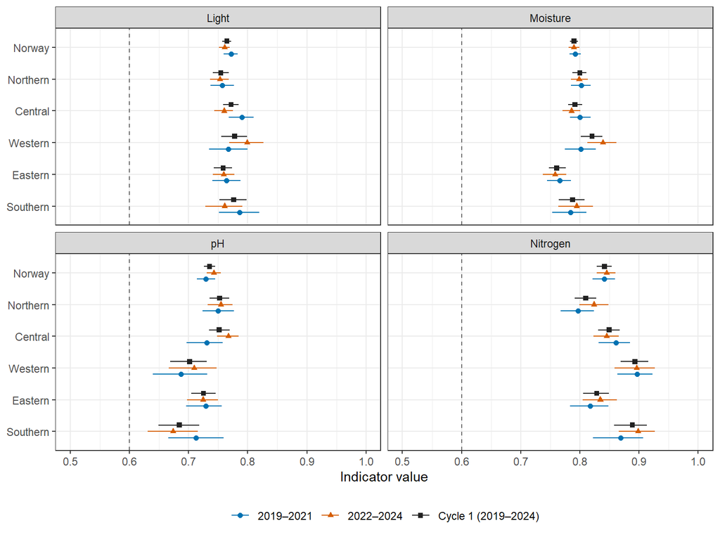

Figure 1: Indicator values by region and period, with 95% intervals. The dashed line is the limit for good condition (0.6). Cycle 1 shares most of its surveys with the other two periods.

Table 5: Direction of the deviations, Norway, cycle 1: number of plots on each side of the reference median, and the mean value of those plots. Nitrogen is one-sided, so only plots with enrichment are counted.

| Indicator | Plots below | Mean below | Plots above | Mean above |
| --- | --- | --- | --- | --- |
| Light | 1,970 | 0.77 | 808 | 0.76 |
| Moisture | 2,303 | 0.79 | 475 | 0.82 |
| pH | 2,138 | 0.71 | 640 | 0.84 |
| Nitrogen | – | – | 1,146 | – |

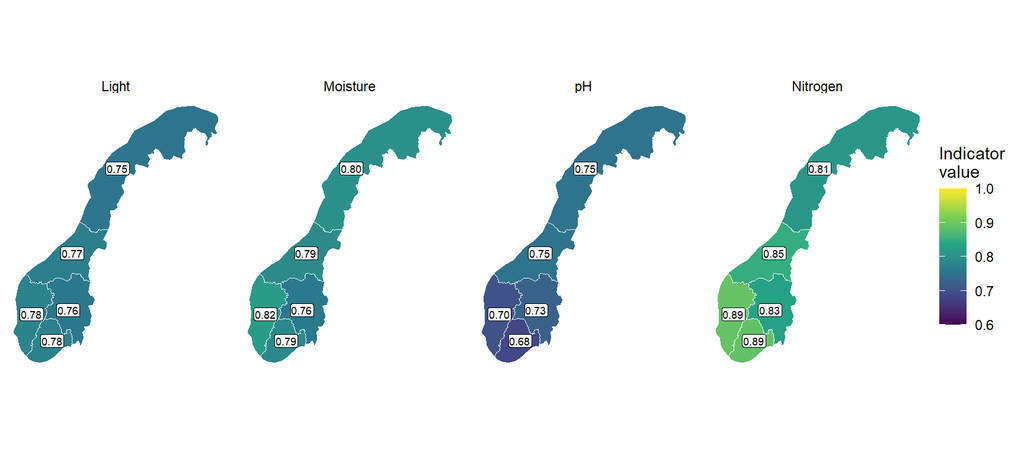

Figure 2: Indicator values per region, ANO cycle 1 (2019–2024)

### 10.2 Distribution of plot values

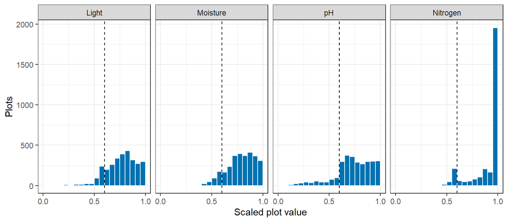

Figure 3: Distribution of scaled plot values, all surveys 2019–2024. The dashed line is 0.6.

### 10.3 Combined index (not delivered)

The pipeline also calculates the combined index of NINA’s NO_FUNC indicators. It is not part of the delivery, and its files are in `outputs/supplementary/`. It takes the lowest of the eight scaled sides per plot, uses the 0.25 and 0.75 quantiles as limits (as in NINA’s code for NO_FUNC_001–004; the text of that document states 0.025 and 0.975), and is aggregated as a median. Its values are not comparable with the four indicators above.

Table 6: Combined index VAAT-FUNC-01: median [95% bootstrap interval], n = plots

| Region | 2019–2021 | 2022–2024 | Cycle 1 (2019–2024) |
| --- | --- | --- | --- |
| Norway | 0.45 [0.44–0.46], n = 1,245 | 0.46 [0.45–0.47], n = 1,709 | 0.46 [0.45–0.47], n = 2,778 |
| Northern | 0.48 [0.46–0.50], n = 380 | 0.49 [0.47–0.50], n = 542 | 0.49 [0.48–0.49], n = 863 |
| Central | 0.44 [0.41–0.47], n = 330 | 0.48 [0.46–0.49], n = 581 | 0.47 [0.45–0.48], n = 858 |
| Western | 0.42 [0.40–0.46], n = 135 | 0.41 [0.40–0.47], n = 112 | 0.42 [0.40–0.46], n = 226 |
| Eastern | 0.44 [0.41–0.47], n = 288 | 0.41 [0.39–0.44], n = 362 | 0.42 [0.40–0.44], n = 626 |
| Southern | 0.41 [0.38–0.45], n = 112 | 0.37 [0.34–0.41], n = 112 | 0.38 [0.36–0.40], n = 205 |

## 11. Export file

The results are written to disk by the code below and converted to the ecosystemCondition platform format by `R/export_deliverables.R`, which writes to `outputs/deliverables/`.

```r
# ===========================================================
# STAGE 11: Write the final tables to disk (no computation happens here).
#   outputs/results/VAAT-FUNC-01_index_by_region_period.csv   (VAAT-FUNC-01)
#   outputs/results/VAAT-FUNC-01_supp_indicators.csv          (VAAT-FUNC-01_supp)
#   outputs/results/VAAT-FUNC-01_by_round.csv                 (VAAT-FUNC-01_by_round)
#   outputs/results/VAAT-FUNC-01_factor_indicators.csv        (VAAT-FUNC-01_factors: the four
#     separate indicators NO_FULI/FUMO/FUPH/VAAT-FUNI-01 per period x region)
#   outputs/results/VAAT-FUNC-01_plots.gpkg / .csv            one row per ANO plot
#     visit: identifiers (site, point), year, visit number/round, region,
#     NiN unit, the 8 scaled
#     indicators, fpci.min, and the 4 raw CWM values (native trait units).
# R/export_deliverables.R reads these and produces the platform-format
# files under outputs/deliverables/.
# ===========================================================

results_dir <- file.path("..", "outputs", "results")
if (!dir.exists(results_dir)) dir.create(results_dir, recursive = TRUE)

readr::write_csv(VAAT_FUNC_01,          file.path(results_dir, "VAAT-FUNC-01_index_by_region_period.csv"))
readr::write_csv(VAAT_FUNC_01_supp,     file.path(results_dir, "VAAT-FUNC-01_supp_indicators.csv"))
readr::write_csv(VAAT_FUNC_01_by_round, file.path(results_dir, "VAAT-FUNC-01_by_round.csv"))
readr::write_csv(VAAT_FUNC_01_factors,  file.path(results_dir, "VAAT-FUNC-01_factor_indicators.csv"))

# results.wet[["original"]] and res.wet are row-aligned copies of ANO.wet
# (Stage 7/8), so the raw CWMs are attached by position - NOT joined on
# GlobalID, which is NA for the plots without species records and would
# cross-multiply those rows.
raw_cwm <- results.wet[["original"]] |>
  select(cwm_Light = Light1, cwm_Moisture = Moist1, cwm_pH = pH1, cwm_Nitrogen = Nitrogen1, richness)
stopifnot(nrow(raw_cwm) == nrow(res.wet))

plots_out <- res.wet |>
  mutate(GlobalID = as.character(GlobalID), region = str_remove(region, "\\.Norway$")) |>
  select(GlobalID, ano_flate_id, ano_punkt_id, aar, ano_visit, ano_round, region, kartleggingsenhet_1m2,
         all_of(wet_indicators), fpci.min,
         starts_with("fac_")) |>
  bind_cols(raw_cwm) |>
  filter(!is.na(aar))   # drop rows that never had a survey record

sf::st_write(plots_out, file.path(results_dir, "VAAT-FUNC-01_plots.gpkg"), delete_dsn = TRUE, quiet = TRUE)
readr::write_csv(sf::st_drop_geometry(plots_out), file.path(results_dir, "VAAT-FUNC-01_plots.csv"))
cat("\nStage 11: tables written to", results_dir, "-", nrow(plots_out), "plot visits\n")
```

## 12. Author contributions

**CRediT statement**

- Software (code development): JACB, LK
- Validation (assessment): JACB, LK
- Writing of the project report: BS, JACB

BS: Bendik Sivertsen. JACB: Jesus Adrian Chimal-Ballesteros. LK: Lasse Keetz.

AI tools: Claude (Anthropic) was used for code development and review, for running and checking analyses, and for drafting this document. The use is described in the repository README.

**TipSession Info**

This is the R session that rendered the document, not the one that produced the results. The package versions of the analysis are in `renv.lock`.